# Tutorial 1: Introduction and Expressions

Programming for Engineers (ENGG1001)

Published

January 30, 2026

## About Tutorials

The aim of the ENGG1001 tutorial sessions is to give additional practice at writing computer programs. The tasks are designed to be completed by a group of two or three students working together, so it is strongly recommended that you sit with other students. Making use of the course notes and lecture material is also encouraged.

Tutors are present at the session to provide assistance and insight into the tasks, so ask them questions when you get stuck. Note that tutors **will not provide assistance** for the assignment tasks in the Tutorial sessions; for that, you should go to the **help centre** (which is at **[78-217](https://maps.uq.edu.au/?campusId=406&zLevel=2&zoom=18&identifier=fff6afea98a2e945b41959a01ff9d2698a80bb4a2abbd32b9fdc9218404a5a12)** General Purpose South).

Attendance at these sessions is not marked, however you will miss out on learning opportunities by not attending. Students often find that the learning experiences from the tutorials are directly helpful in completing the assignments and the final exam.

## Setting up Python

Before we begin our journey into the world of python, we need to install the necessary libraries. Libraries are essentially large amounts of code that developers have written to make our lives easier, and we will be using them in the coming weeks.

Libraries are essentially large amounts of code that developers have written to make our lives easier, and we will be using them in the coming weeks. Your assignments will be utilising these libraries, so it is critical that you install these immediately.

In order to work with Python, we first need an Integrated Development Environment (IDE). In ENGG1001, we recommend IDLE (though any IDE is fine). An IDE is basically a text editor that is tailored designed to work with computer code.

1. Ensure that you have Python installed on your computer. If python is not installed, then head to the [Python website](https://www.python.org/downloads/) and download the Python install manager for your operating system (Windows, MacOS, Linux). Follow the installation instructions on the website to install Python.
2. Open up your command line interface (CLI). On Windows, this is called Command Prompt, and on MacOS or Linux, this is called Terminal.
3. Type the following command into the terminal and press Enter/Return on your keyboard:
   - **Windows:**

     ```bash
     py -m pip install numpy matplotlib pandas
     ```

   - **MacOS/Linux:**

     ```bash
     python3 -m pip install numpy matplotlib pandas
     ```

4. Wait for the installation to complete. You should see a message indicating that the installation was successful. If you enounter a message saying that “pip is out of date” then you can update pip by running the following command:
   - **Windows:**

     ```bash
     py -m pip install --upgrade pip
     ```

   - **MacOS/Linux:**

     ```bash
     python3 -m pip install --upgrade pip
     ```

## Introduction to REPL (Read-Eval-Print Loop)

In this tutorial, we will be using the Python REPL (Read-Eval-Print Loop) to execute Python commands interactively. The REPL allows us to type in Python code and see the results immediately, which is great for learning and experimenting with code.

Try typing 10 + 5 into the REPL, then press Enter (return on some keyboards) on your keyboard. You should see something like this:

10 + 5

15

Notice that the REPL has evaluated your addition, and displayed the result on a line without arrows. This is how you can see which statements are inputs and which are outputs. You should also notice that you do not need to type the arrows.

You can also enter strings into the REPL. Try typing “Hello, Wordl!” into the REPL (be sure to include the ” symbols at each end) and press Enter on your keyboard. You should see the REPL display your text back to you, like this:

"Hello, World!"

'Hello, World!'

An important concept in Python is the use of variables. Similar to mathematics, variables store some sort of value. We can use letters or words to represent any variable, and we assign a value to it using the equals sign (=). For example, if you want to store the number 2 inside a variable named a, you would type a = 2. Try this in your REPL.

a = 2

Notice that the REPL did not display anything after this statement. This is because assigning a value does not have anything to evaluate, so there is no output. However, if you want to view the value stored in a variable, you can type that variable into the REPL and press enter, and the value will be given as output. Try this with a.

a

2

Variables can (and generally should) be represented by words too. Try storing the value 100 inside a variable `one_hundred`. You cannot have spaces in your variable names, but you can use underscores instead.

one_hundred = 100

one_hundred

100

You can also use the variables to do arithmetic. Try dividing one_hundred by a and assigning the result to a new variable called result. Display your result variable and check it is the value you expect.

result = one_hundred / a

result

50.0

The value stored in variables can be overwritten at any time. Try assigning a string to the result variable, then displaying result. You should see that it now has the new value you just assigned, rather than the number it had before.

result

50.0

result = "This was my result, but now it is a String."

result

'This was my result, but now it is a String.'

## Running Files

The REPL is useful for running small pieces of code, but makes it difficult to create or maintain longer programs. To do this, `.py` files are used.

Create a new file by selecting ‘New’ from the File menu in IDLE, or using the `Ctrl-N` (`Cmd-N` on Mac) shortcut. Notice that this window does not have the arrows on the left hand side. Select ‘New’ from the File menu:

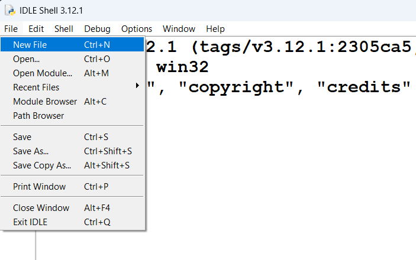

Figure 1: New File Button

This should open an empty file window - notice there are no arrows on the side:

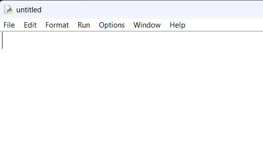

Figure 2: The New File window in IDLE

In order to run anything, this file will first need to be saved. Save the file by selecting ‘Save’ from the File menu, or by using the `Ctrl-S` (or `Cmd-S`) shortcut. Save the file in a location you will be able to find it as `hello.py`.

Code can be written in this file just like in the REPL, but it will not be evaluated until the entire file is run. Write the following code into your hello.py file (replace “Steve” with your own name if you like!):

```
hello.py
```

```python
num_one = 10
num_two = 5
course = "ENGG1001"
name = "Steve"
num_one + num_two
```

Now try running your file. You can do this by selecting ‘Run Module’ in the ‘Run’ menu as shown below:

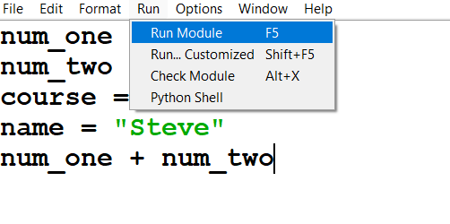

Figure 3: Run Module Button

If you have unsaved changes, you will be prompted to save the file before continuing - select ‘Ok’ if this happens. On running the file, you should see something like, but not eactly, this appear in the REPL:

============= RESTART H:/ENGG1001/PythonCode/Week1/hello.py =============

Even though the file had a statement we would expect the REPL to evaluate (in this case num_one + num_two), because it was inside the file it does not get displayed. However, if you type any of the variable names from the file into the REPL after running the file, the relevant value will be output.

name

'Steve'

name = "Stephen"

name

'Stephen'

The next time you run the file, those variables will revert back to their original values.

============= RESTART H:/ENGG1001/PythonCode/Week1/hello.py =============

name

'Steve'

What if you want to display a value in the REPL directly from your file, without typing a variable name? To do this, you use the print() function. Change line 5 of your file from num_one + num_two to print(num_one + num_two):

```
hello.py
```

```python
num_one = 10
num_two = 5
course = "ENGG1001"
name = "Steve"
print(num_one + num_two)
```

Output

```
15
```

You should see the value output, like you would expect had you typed the value into the REPL.

## Tutorial Tasks

- Task 1: Modify `hello.py` to greet the user by name.
- Task 2: Modify `hello.py` to ask the user their name, then greet them.
- Task 3: Guess the Expression!

## Task 1: greeting the user

Try modifying your file and using the variables so that when you run it, it greets you and welcomes you to the course.

**Tip**

You can join two or more strings by using the `+` sign between them.

============= RESTART H:/ENGG1001/PythonCode/Week1/hello.py =============

Hello Steve! Welcome to ENGG1001.

Here is one way to complete Task 1:

```
hello.py
```

```python
course = "ENGG1001"
name = "Steve"
print("Hello " + name + "! Welcome to " + course +'.')
```

Output

```
Hello Steve! Welcome to ENGG1001.
```

## Task 2: Ask the user their name

Next, modify your file to first ask the user what their name is (using input), and then output a greeting using their name. For example:

============= RESTART H:/ENGG1001/PythonCode/Week1/hello.py =============

What is your name? Steve Jobs

Hello Steve Jobs! Welcome to ENGG1001.

**Tip**

You you should use `input()` function to get input from the user! Please note that any value typed by the user on the keyboard is read as a string.

## Task 3: Guess the Expression!

For each of the below expressions, make a guess on what the result of the expression should be. Discuss your guesses with the other people at your table, or with a tutor, before running the code in IDLE. After running the code, if you didn’t guess correctly, discuss why it produced the result that it did, or experiment with some other examples yourself.

3 -- 2

5 / 2

-5 / 2

5 // 2

-5 // 2

5.0 / 2

5.0 // 2

3.0 - 5 / 2

3.0 - 5 // 2

'3' + '12'

3 + '12'

3 * '12'

'ba' + 'na' * 2

'hello' - 'o'

'ababab' / 3

2 ** 3

9 ** 1/2

11 % 4

-11 % 4

'Tim' > 'Tom'

'A' < 'a'

```python
print(3 -- 2)
```

Output

```
5
```

```python
print(5 / 2)
```

Output

```
2.5
```

```python
print(-5 / 2)
```

Output

```
-2.5
```

```python
print(5 // 2)
# this is known as integer (or floor) division,
# It's normal division but rounds down to the nearest whole number
```

Output

```
2
```

```python
print(-5 // 2)
# notice that -2.5 rounds down to -3, not up to -2
```

Output

```
-3
```

```python
print(5.0 / 2)
```

Output

```
2.5
```

```python
print(5.0 // 2)
# note that since we specified 5.0 as a float, the result is also a float
```

Output

```
2.0
```

```python
print(3.0 - 5 / 2)
# once again, since 3.0 is a float, the result is also a float
```

Output

```
0.5
```

```python
print(3.0 - 5 // 2)
# same logic as above
```

Output

```
1.0
```

```python
print('3' + '12')
# the + operator concatenates (joins) strings together
```

Output

```
312
```

```python
print(3 + '12')
# you cannot add a number and a string together
```

Output

```
---------------------------------------------------------------------------
TypeError                                 Traceback (most recent call last)
Cell In[13], line 1
----> 1 print(3 + '12')
      2 # you cannot add a number and a string together

TypeError: unsupported operand type(s) for +: 'int' and 'str'
```

```python
print(3 * '12')
# the * operator repeats the string a certain number of times
```

Output

```
121212
```

```python
print('ba' + 'na' * 2)
# note that the * operator has higher precedence than +
# in other words, python follows the order of operations
```

Output

```
banana
```

```python
print('hello' - 'o')
# there is no subtraction operator for strings
```

Output

```
---------------------------------------------------------------------------
TypeError                                 Traceback (most recent call last)
Cell In[16], line 1
----> 1 print('hello' - 'o')
      2 # there is no subtraction operator for strings

TypeError: unsupported operand type(s) for -: 'str' and 'str'
```

```python
print('ababab' / 3)
# there is no division operator for strings
```

Output

```
---------------------------------------------------------------------------
TypeError                                 Traceback (most recent call last)
Cell In[17], line 1
----> 1 print('ababab' / 3)
      2 # there is no division operator for strings

TypeError: unsupported operand type(s) for /: 'str' and 'int'
```

```python
print(2 ** 3)
# the ** operator is exponentiation (power)
```

Output

```
8
```

```python
print(9 ** 1/2)
# this is equivalent to (9 ** 1) / 2 = 9 / 2 = 4.5
# to get the square root, you need to use 9 ** (1/2)
```

Output

```
4.5
```

```python
print(11 % 4)
# the % operator is the modulus operator,
# which gives the remainder after division
```

Output

```
3
```

```python
print(-11 % 4)
# in python, if we get a negative remainder,
# we add the divisor (4) to it to get a positive remainder
```

Output

```
1
```

```python
print('Tim' > 'Tom')
# string comparison is done in alphabetical order, it compares
#  the first differing character based on their unicode values
```

Output

```
False
```

```python
print('A' < 'a')
# uppercase letters have lower unicode values than lowercase letters
# so 'A' is considered less than 'a'
```

Output

```
True
```